# El juego del tejo, errores y aciertos

Gabriel González Medina

24-12-2020

## INTRODUCCIÓN

En este escrito doy una primera aproximación al uso de R y conceptos estadísticos para realizar modelos predictos, a traves del **juego del tejo**

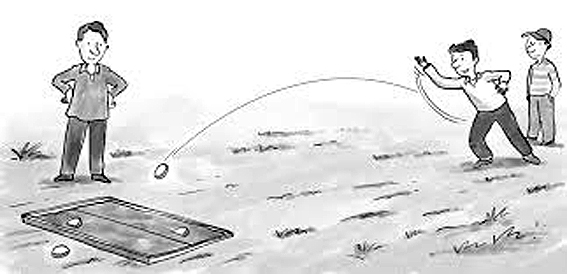

En mi país, Chile, es un juego común en el ambiente rural, y sobre todo en las fiestas nacionales, los 18 de septiembre. De hecho, tengo el recuerdo con mi familia cuando niño, en Cabildo, haciendo varios juegos tradicionales, y entre estos tenían que prepar el terreno de juego para el tejo. aunque acá en Chile, tambien le dicen **“La Rayuela”**, pero en otros paises lationaméricanos, le dicen la Rayuela a lo que nosotros le decimos **“El Luche”**. Bueno, todo un enredo, que no vamos a profundizar.

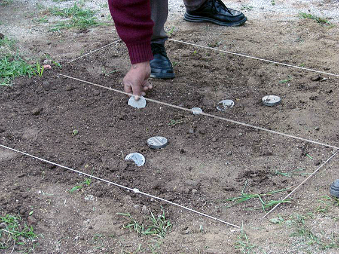

De acuerdo, a lo que encontré en [internet, “Revista Chilena”](http://www.revistachilena.com/La_Rayuela.html), el cajon de juego es de 120 cm largo y 120 ancho y la linea donde debe caer el tejo para marcar una “quemada” y obtener 2 puntos está a 60 cm horizontalmente en el cajon, de lado a lado.

## Registro de los datos

Vamos a empezar con algo bastante simple, los registros que podríamos haber sido anotados manualmente en una hoja de papel.

En este escenario tenemos dos jugadores que tiraron tres veces cada uno, el arbitro luego de cada lanzamiento media con una regla la sitancia en que caí el tejo desde el comienzo del cajon.

Entonces, en su libreta de notas el indico qué:

jugador 1 = 60, 80, 40

jugador 2 = 70, 65, 55

Escribirlo en el lenguaje de R, sería de la siguiente forma:

```r
j1 <- c(60, 80, 40)
j2 <- c(70, 65, 55)
```

Lo transformó ahora en un **data frame**, para que nos quedé listo para trabajar más adelante. Digamos que en una forma tabulada, como en una planilla excel, o un viejo cuaderno de matematicas con lineas verticales y horizontales.

```r
puntos <- data.frame(rbind(j1,j2))
```

Les pondemos nombre a las variables, para recordar qué es qué

```r
colnames(puntos) <- c("intento1", "intento2", "intento3")
```

Ahora creo una variable para distinguir a los jugadores

```r
library(dplyr) #Cargamos el paquete necesario para poder hacer lo siguiente

puntos <- puntos %>%
  mutate(jugador = rownames(puntos))
```

## Gráficos

Luego graficamos los resultados del primer intento

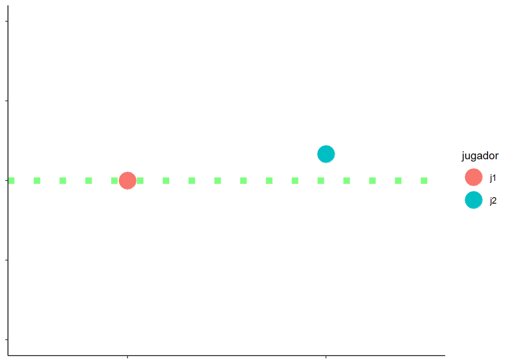

```r
library(ggplot2) #llamamos el paquete para graficar
ggplot(puntos, aes(jugador, intento1, color = jugador)) +
  geom_point(size = 8) + #En este parte le doy el tamaño a los tejos
  geom_hline(yintercept =  60, color = "green", linetype = "dotted",
             size = 3, alpha = 0.5) + #luego creo la linea con la que se gana
  scale_y_continuous(limits = c(0,120),  breaks = c(0,30,60, 90, 120))+
  theme_classic() +
  theme( axis.text.x = element_blank(),
         axis.title.y = element_blank(),
         axis.text.y = element_blank(),
         axis.title.x = element_blank()
  ) #y toda esta ultima parte es para limpiar el gráfico y solo queden elementos principales
```

Tenemos que ajustar la base de datos si queremos poder graficar todos los intentos en un gráfico

```r
library(tidyr)

puntos <- puntos %>%
  pivot_longer(cols = -jugador, names_to = "intento", names_prefix = "intento",
               values_to = "distancia")
```

Graficar todo el juego completo

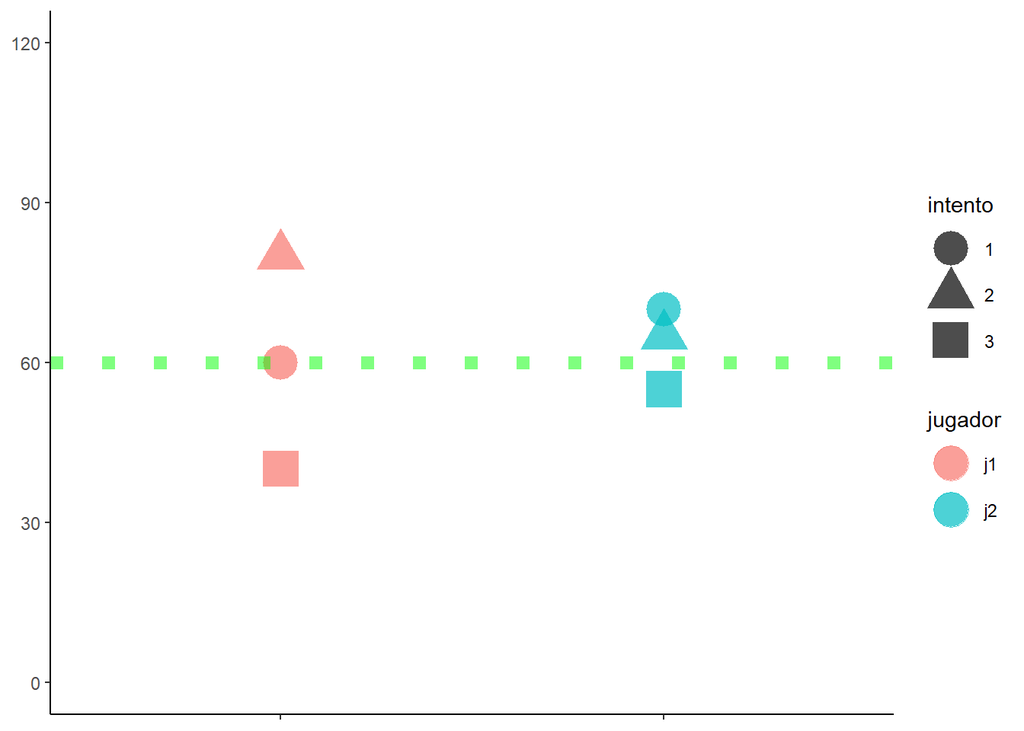

```r
ggplot(puntos, aes(jugador, distancia, shape = intento, color = jugador)) +
  geom_point(size = 8, alpha = 0.7) +
  geom_hline(yintercept =  60, color = "green", linetype = "dotted",
             size = 3, alpha = 0.5) +
  scale_y_continuous(limits = c(0,120), breaks = c(0,30,60, 90, 120))+
  theme_classic() +
  theme(axis.text.x = element_blank(),
        axis.title.x = element_blank(),
        axis.title.y = element_blank()
  )
```

### Los errores

Calculamos la **diferencia** entre donde cayó el tejo y la linea objetivo

```r
puntos <- puntos %>%
  mutate(diferencia = distancia - 60)
print(puntos)
```

```
## # A tibble: 6 x 4
##   jugador intento distancia diferencia
##   <chr>   <chr>       <dbl>      <dbl>
## 1 j1      1              60          0
## 2 j1      2              80         20
## 3 j1      3              40        -20
## 4 j2      1              70         10
## 5 j2      2              65          5
## 6 j2      3              55         -5
```

Graficamos ahora con esta nueva variable, usandola como una etiqueta.

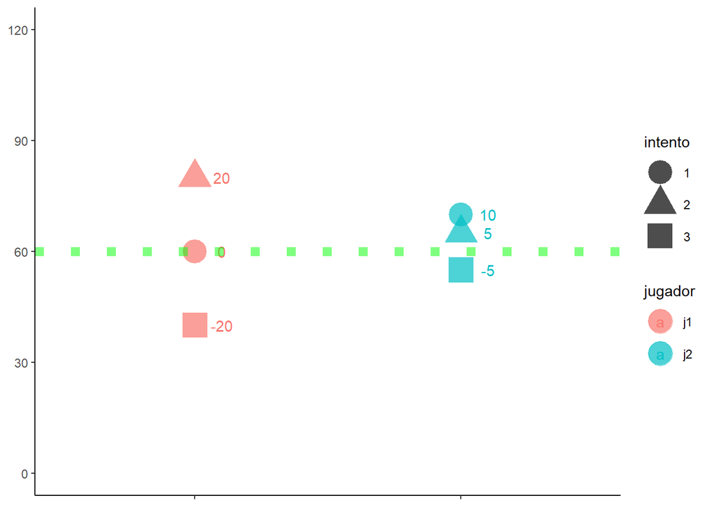

```r
ggplot(puntos, aes(jugador, distancia, shape = intento, color = jugador)) +
  geom_point(size = 8, alpha = 0.7) +
  geom_text(aes(label = diferencia), position = position_nudge(x=0.1))+
  #anotamos con esta nueva linea la diferencia en el grafico
  geom_hline(yintercept =  60, color = "green", linetype = "dotted",
             size = 3, alpha = 0.5) +
  scale_y_continuous(limits = c(0,120), breaks = c(0,30,60, 90, 120))+
  theme_classic() +
  theme(axis.text.x = element_blank(),
        axis.title.x = element_blank(),
        axis.title.y = element_blank()
  )
```

calculemos el desempeño **promedio** de cada jugador

```r
puntos <- puntos %>%
  group_by(jugador) %>%  #primero agrupar datos por jugador
  mutate(promedio_jugador = mean(distancia))

print(puntos)
```

```
## # A tibble: 6 x 5
## # Groups:   jugador [2]
##   jugador intento distancia diferencia promedio_jugador
##   <chr>   <chr>       <dbl>      <dbl>            <dbl>
## 1 j1      1              60          0             60
## 2 j1      2              80         20             60
## 3 j1      3              40        -20             60
## 4 j2      1              70         10             63.3
## 5 j2      2              65          5             63.3
## 6 j2      3              55         -5             63.3
```

Si vemos los resultados, en promedio el jugador 1 cayó en lugar de la linea, es decir es el ganador. Pero otra manera de resumir el desempeño general es promediando cuanto se equivocó

```r
puntos <- puntos %>%
  group_by(jugador) %>%  #primero agrupar datos por jugador
  mutate(promedio_diferencia = mean(diferencia)) %>%
  mutate(promedio_diferencia_absoluta = sqrt(mean(diferencia^2)))
#en la última linea, se elevó la diferencia al cruadrado para dejarlo en una medida #absoluta del error de cada jugador con ^2 y luego se volvió a la medida original
#usando sqrt(), esto es,  la raiz cuadrada

print(puntos)
```

```
## # A tibble: 6 x 7
## # Groups:   jugador [2]
##   jugador intento distancia diferencia promedio_jugador promedio_difere~
##   <chr>   <chr>       <dbl>      <dbl>            <dbl>            <dbl>
## 1 j1      1              60          0             60               0
## 2 j1      2              80         20             60               0
## 3 j1      3              40        -20             60               0
## 4 j2      1              70         10             63.3             3.33
## 5 j2      2              65          5             63.3             3.33
## 6 j2      3              55         -5             63.3             3.33
## # ... with 1 more variable: promedio_diferencia_absoluta <dbl>
```

## Los Aciertos

Luego, podemos tambien crear una nueva variable **dictomica** que define si el intento acertó o no.

```r
puntos <- puntos %>%
mutate(resultado = ifelse(diferencia  == 0, "Acierto", "Fallo"))

#entonces, si la diferencia es 0, significá que acertó. Cualquier otro numero será
#un fallo.

#Y entonces hacemos un tabla para resumir los resultados

table(puntos$resultado, puntos$jugador)
```

```
##
##           j1 j2
##   Acierto  1  0
##   Fallo    2  3
```

## REFLEXIONES FINALES

- ¿Que es mejor para evaluar los rendimientos entonces?
- ¿Los promedios?
- ¿Los promedios de los errores?
- ¿Los promedios de los errores absolutos?
- ¿Aciertos vs fallos?

La respuesta para nada sorprendente a todas estas preguntas es **“depende”** una palabra muy usada tanto por la estadística como por la psicología, porque básicamente es muy dificil encontrar algo que no se influenciado o causado por otra cosa. El contexto es sumamente importante para poder tomer una decisión. Seguiré con esto en proximo entregas, para que podamos entender cuando es mejor usar cada cosa.